# WALMART TIME SERIES USING LSTM

```python
!pip install keras
```

```python
# Computational imports
import numpy as np   # Library for n-dimensional arrays
import pandas as pd  # Library for dataframes (structured data)

# Helper imports
import os
import re
import warnings
from tqdm import tqdm
import datetime as dt

# ML/DL imports
from sklearn.preprocessing import MinMaxScaler, OrdinalEncoder, LabelEncoder
from sklearn.metrics import mean_squared_error, mean_squared_log_error
from sklearn.model_selection import train_test_split

import tensorflow as tf
from tensorflow.keras.models import Sequential
from tensorflow.keras.layers import LSTM, Dense, Dropout, RepeatVector, TimeDistributed
from tensorflow.keras.callbacks import ModelCheckpoint, EarlyStopping

# Plotting imports
import matplotlib.pyplot as plt
import matplotlib.dates as dates
import plotly.express as px
import plotly.graph_objects as go
import plotly.figure_factory as ff
from plotly.subplots import make_subplots
from plotly.offline import init_notebook_mode, iplot

%matplotlib inline
warnings.filterwarnings("ignore")
init_notebook_mode(connected=True)

# Set seeds to make the experiment more reproducible.
from numpy.random import seed
seed(1)

# Allows us to see more information regarding the DataFrame
pd.set_option("display.max_rows", 500)
pd.set_option("display.max_columns", 500)
```

## This functions is used to quickly check the shapes of our numpy arrays. This is especially important to assure we have the right shape for our LSTM network.

```python
def show_shapes(Sequences, Targets): # this'll use inputs; can make yours to use local variable values
    print("Expected: (num_samples, timesteps, channels)")
    print("Sequences: {}".format(Sequences.shape))
    print("Targets:   {}".format(Targets.shape))
```

# This functions is used to downcast our variables to types that take less memory. This helps with model performance and speed.

```python
def reduce_memory_dtpes(df):
    float_cols = [c for c in df if df[c].dtype == "float64"]
    int_cols = [c for c in df if df[c].dtype in ["int64", "int32"]]
    df[float_cols] = df[float_cols].astype(np.float32)
    df[int_cols] = df[int_cols].astype(np.int16)
    return df
```

## **A key component of time-series problem is splitting our input data into sequences that we can feed to our LSTM network. This sequences depend on the required timesteps and horizons.**

```python
def split_sequences(sequences, timesteps, horizon):
    Sequences, Targets = list(), list()
    for i in range(len(sequences)):
        # find the end of this pattern
        end_ix = i + timesteps
        out_end_ix = end_ix + horizon-1
        # check if we are beyond the dataset
        if out_end_ix > len(sequences):
            break
        # gather input and output parts of the pattern
        seq_x, seq_y = sequences[i:end_ix, :-1], sequences[end_ix-1:out_end_ix, -1]
        Sequences.append(seq_x)
        Targets.append(seq_y)
        show_shapes()
    return array(X), array(y)
```

```python
def transform(data):

    nan_features = ['event_name_1', 'event_type_1', 'event_name_2', 'event_type_2']
    for feature in nan_features:
        data[feature].fillna('unknown', inplace = True)

    cat = ['event_name_1','event_type_1','event_name_2','event_type_2','snap_CA','snap_TX','snap_WI']
    for feature in cat:
        encoder = LabelEncoder()
        data[feature] = encoder.fit_transform(data[feature])

    return data
```

# These functions are used to normalize our data. This aids with model performance and speed. You can also use the scikit-learn MinMaxScaler if you wish, it is up to you

```python
def Normalize(list):
    list = np.array(list)
    low, high = np.percentile(list, [0, 100])
    delta = high - low
    if delta != 0:
        for i in range(0, len(list)):
            list[i] = (list[i]-low)/delta
    return  list,low,high

def FNoramlize(list,low,high):
    delta = high - low
    if delta != 0:
        for i in range(0, len(list)):
            list[i] = list[i]*delta + low
    return list

def Normalize2(list,low,high):
    list = np.array(list)
    delta = high - low
    if delta != 0:
        for i in range(0, len(list)):
            list[i] = (list[i]-low)/delta
    return  list
```

```python
path = '/content/drive/MyDrive/'

train_data = pd.read_csv(path+ '/sales_train_validation.csv')
calendar = pd.read_csv(path + '/calendar.csv')
sell_prices = pd.read_csv(path + '/sell_prices.csv')
submission_file = pd.read_csv(path + '/sample_submission.csv')
```

```python
train_data.describe()
```

|  | d_1 | d_2 | d_3 | d_4 | d_5 | d_6 | d_7 | d_8 | d_9 | d_10 | d_11 | d_12 | d_13 | d_14 | d_15 | d_16 | d_17 | d_18 | d_19 | d_20 | d_21 | d_22 | d_23 | d_24 | d_25 | d_26 | d_27 | d_28 | d_29 | … |
| --- | --- | --- | --- | --- | --- | --- | --- | --- | --- | --- | --- | --- | --- | --- | --- | --- | --- | --- | --- | --- | --- | --- | --- | --- | --- | --- | --- | --- | --- | --- |
| count | 30490.000000 | 30490.000000 | 30490.000000 | 30490.000000 | 30490.000000 | 30490.000000 | 30490.000000 | 30490.000000 | 30490.000000 | 30490.000000 | 30490.000000 | 30490.000000 | 30490.000000 | 30490.000000 | 30490.000000 | 30490.000000 | 30490.000000 | 30490.000000 | 30490.000000 | 30490.000000 | 30490.000000 | 30490.000000 | 30490.000000 | 30490.000000 | 30490.000000 | 30490.000000 | 30490.000000 | 30490.000000 | 30490.000000 | … |
| mean | 1.070220 | 1.041292 | 0.780026 | 0.833454 | 0.627944 | 0.958052 | 0.918662 | 1.244080 | 1.073663 | 0.838701 | 0.756674 | 0.775927 | 0.779141 | 0.867334 | 1.142440 | 1.193178 | 0.715120 | 0.789439 | 0.703280 | 0.666382 | 0.777993 | 1.039324 | 0.960413 | 0.786028 | 0.672384 | 0.680781 | 0.665038 | 0.738898 | 0.980912 | … |
| std | 5.126689 | 5.365468 | 3.667454 | 4.415141 | 3.379344 | 4.785947 | 5.059495 | 6.617729 | 5.917204 | 4.206199 | 3.665969 | 3.697822 | 3.486595 | 3.484608 | 4.636395 | 4.662770 | 2.993414 | 3.296922 | 2.811648 | 2.611911 | 2.985123 | 3.923110 | 3.597620 | 3.084773 | 2.874189 | 2.727852 | 2.637849 | 2.842334 | 3.714944 | … |
| min | 0.000000 | 0.000000 | 0.000000 | 0.000000 | 0.000000 | 0.000000 | 0.000000 | 0.000000 | 0.000000 | 0.000000 | 0.000000 | 0.000000 | 0.000000 | 0.000000 | 0.000000 | 0.000000 | 0.000000 | 0.000000 | 0.000000 | 0.000000 | 0.000000 | 0.000000 | 0.000000 | 0.000000 | 0.000000 | 0.000000 | 0.000000 | 0.000000 | 0.000000 | … |
| 25% | 0.000000 | 0.000000 | 0.000000 | 0.000000 | 0.000000 | 0.000000 | 0.000000 | 0.000000 | 0.000000 | 0.000000 | 0.000000 | 0.000000 | 0.000000 | 0.000000 | 0.000000 | 0.000000 | 0.000000 | 0.000000 | 0.000000 | 0.000000 | 0.000000 | 0.000000 | 0.000000 | 0.000000 | 0.000000 | 0.000000 | 0.000000 | 0.000000 | 0.000000 | … |
| 50% | 0.000000 | 0.000000 | 0.000000 | 0.000000 | 0.000000 | 0.000000 | 0.000000 | 0.000000 | 0.000000 | 0.000000 | 0.000000 | 0.000000 | 0.000000 | 0.000000 | 0.000000 | 0.000000 | 0.000000 | 0.000000 | 0.000000 | 0.000000 | 0.000000 | 0.000000 | 0.000000 | 0.000000 | 0.000000 | 0.000000 | 0.000000 | 0.000000 | 0.000000 | … |
| 75% | 0.000000 | 0.000000 | 0.000000 | 0.000000 | 0.000000 | 0.000000 | 0.000000 | 0.000000 | 0.000000 | 0.000000 | 0.000000 | 0.000000 | 0.000000 | 0.000000 | 0.000000 | 0.000000 | 0.000000 | 0.000000 | 0.000000 | 0.000000 | 0.000000 | 0.000000 | 0.000000 | 0.000000 | 0.000000 | 0.000000 | 0.000000 | 0.000000 | 0.000000 | … |
| max | 360.000000 | 436.000000 | 207.000000 | 323.000000 | 296.000000 | 314.000000 | 316.000000 | 370.000000 | 385.000000 | 353.000000 | 279.000000 | 258.000000 | 163.000000 | 107.000000 | 133.000000 | 149.000000 | 122.000000 | 111.000000 | 83.000000 | 95.000000 | 100.000000 | 132.000000 | 120.000000 | 113.000000 | 158.000000 | 105.000000 | 104.000000 | 94.000000 | 125.000000 | … |

8 rows × 1913 columns

# **Let's prepare our data. We will manipulate and transform the data and make it more convenient for us to use.**

```python
days = range(1, 1970)
time_series_columns = [f'd_{i}' for i in days]
transfer_cal = pd.DataFrame(calendar[['event_name_1','event_type_1','event_name_2','event_type_2','snap_CA','snap_TX','snap_WI']].values.T, index=['event_name_1','event_type_1','event_name_2','event_type_2','snap_CA','snap_TX','snap_WI'], columns= time_series_columns)
transfer_cal = transfer_cal.fillna(0)
event_name_1_se = transfer_cal.loc['event_name_1'].apply(lambda x: x if re.search("^\d+$", str(x)) else np.nan).fillna(10)
event_name_2_se = transfer_cal.loc['event_name_2'].apply(lambda x: x if re.search("^\d+$", str(x)) else np.nan).fillna(10)
```

```python
transfer_cal.head()
```

|  | d_1 | d_2 | d_3 | d_4 | d_5 | d_6 | d_7 | d_8 | d_9 | d_10 | d_11 | d_12 | d_13 | d_14 | d_15 | d_16 | d_17 | d_18 | d_19 | d_20 | d_21 | d_22 | d_23 | d_24 | d_25 | d_26 | d_27 | d_28 | d_29 | … |
| --- | --- | --- | --- | --- | --- | --- | --- | --- | --- | --- | --- | --- | --- | --- | --- | --- | --- | --- | --- | --- | --- | --- | --- | --- | --- | --- | --- | --- | --- | --- |
| event_name_1 | 0 | 0 | 0 | 0 | 0 | 0 | 0 | 0 | SuperBowl | 0 | 0 | 0 | 0 | 0 | 0 | 0 | ValentinesDay | 0 | 0 | 0 | 0 | 0 | 0 | PresidentsDay | 0 | 0 | 0 | 0 | 0 | … |
| event_type_1 | 0 | 0 | 0 | 0 | 0 | 0 | 0 | 0 | Sporting | 0 | 0 | 0 | 0 | 0 | 0 | 0 | Cultural | 0 | 0 | 0 | 0 | 0 | 0 | National | 0 | 0 | 0 | 0 | 0 | … |
| event_name_2 | 0 | 0 | 0 | 0 | 0 | 0 | 0 | 0 | 0 | 0 | 0 | 0 | 0 | 0 | 0 | 0 | 0 | 0 | 0 | 0 | 0 | 0 | 0 | 0 | 0 | 0 | 0 | 0 | 0 | … |
| event_type_2 | 0 | 0 | 0 | 0 | 0 | 0 | 0 | 0 | 0 | 0 | 0 | 0 | 0 | 0 | 0 | 0 | 0 | 0 | 0 | 0 | 0 | 0 | 0 | 0 | 0 | 0 | 0 | 0 | 0 | … |
| snap_CA | 0 | 0 | 0 | 1 | 1 | 1 | 1 | 1 | 1 | 1 | 1 | 1 | 1 | 0 | 0 | 0 | 0 | 0 | 0 | 0 | 0 | 0 | 0 | 0 | 0 | 0 | 0 | 0 | 0 | … |

5 rows × 1969 columns

```python
event_name_1_se.head()
```

```
d_1    0.0
d_2    0.0
d_3    0.0
d_4    0.0
d_5    0.0
Name: event_name_1, dtype: float64
```

```python
calendar['date'] = pd.to_datetime(calendar['date'])
calendar = calendar[calendar['date']>= '2016-2-01']  # reduce memory
calendar= transform(calendar)
# Attempts to convert events into time series data.
transfer_cal = pd.DataFrame(calendar[['event_name_1','event_type_1','event_name_2','event_type_2','snap_CA','snap_TX','snap_WI']].values.T,
                            index=['event_name_1','event_type_1','event_name_2','event_type_2','snap_CA','snap_TX','snap_WI'])
transfer_cal
```

|  | 0 | 1 | 2 | 3 | 4 | 5 | 6 | 7 | 8 | 9 | 10 | 11 | 12 | 13 | 14 | 15 | 16 | 17 | 18 | 19 | 20 | 21 | 22 | 23 | 24 | 25 | 26 | 27 | 28 | … |
| --- | --- | --- | --- | --- | --- | --- | --- | --- | --- | --- | --- | --- | --- | --- | --- | --- | --- | --- | --- | --- | --- | --- | --- | --- | --- | --- | --- | --- | --- | --- |
| event_name_1 | 16 | 16 | 16 | 16 | 16 | 16 | 14 | 16 | 16 | 2 | 16 | 16 | 16 | 15 | 10 | 16 | 3 | 16 | 16 | 16 | 16 | 16 | 16 | 16 | 16 | 16 | 16 | 16 | 16 | … |
| event_type_1 | 4 | 4 | 4 | 4 | 4 | 4 | 3 | 4 | 4 | 2 | 4 | 4 | 4 | 0 | 1 | 4 | 2 | 4 | 4 | 4 | 4 | 4 | 4 | 4 | 4 | 4 | 4 | 4 | 4 | … |
| event_name_2 | 1 | 1 | 1 | 1 | 1 | 1 | 1 | 1 | 1 | 1 | 1 | 1 | 1 | 1 | 1 | 1 | 1 | 1 | 1 | 1 | 1 | 1 | 1 | 1 | 1 | 1 | 1 | 1 | 1 | … |
| event_type_2 | 1 | 1 | 1 | 1 | 1 | 1 | 1 | 1 | 1 | 1 | 1 | 1 | 1 | 1 | 1 | 1 | 1 | 1 | 1 | 1 | 1 | 1 | 1 | 1 | 1 | 1 | 1 | 1 | 1 | … |
| snap_CA | 1 | 1 | 1 | 1 | 1 | 1 | 1 | 1 | 1 | 1 | 0 | 0 | 0 | 0 | 0 | 0 | 0 | 0 | 0 | 0 | 0 | 0 | 0 | 0 | 0 | 0 | 0 | 0 | 0 | … |
| snap_TX | 1 | 0 | 1 | 0 | 1 | 1 | 1 | 0 | 1 | 0 | 1 | 1 | 1 | 0 | 1 | 0 | 0 | 0 | 0 | 0 | 0 | 0 | 0 | 0 | 0 | 0 | 0 | 0 | 0 | … |
| snap_WI | 0 | 1 | 1 | 0 | 1 | 1 | 0 | 1 | 1 | 0 | 1 | 1 | 0 | 1 | 1 | 0 | 0 | 0 | 0 | 0 | 0 | 0 | 0 | 0 | 0 | 0 | 0 | 0 | 0 | … |

# **Sell Price Data**

```python
price_fea = calendar[['wm_yr_wk','date']].merge(sell_prices, on = ['wm_yr_wk'], how = 'left')
price_fea['id'] = price_fea['item_id']+'_'+price_fea['store_id']+'_validation'
price_fea.head()
```

|  | wm_yr_wk | date | store_id | item_id | sell_price | id |
| --- | --- | --- | --- | --- | --- | --- |
| 0 | 11601 | 2016-02-01 | CA_1 | HOBBIES_1_001 | 8.26 | HOBBIES_1_001_CA_1_validation |
| 1 | 11601 | 2016-02-01 | CA_1 | HOBBIES_1_002 | 3.97 | HOBBIES_1_002_CA_1_validation |
| 2 | 11601 | 2016-02-01 | CA_1 | HOBBIES_1_003 | 2.97 | HOBBIES_1_003_CA_1_validation |
| 3 | 11601 | 2016-02-01 | CA_1 | HOBBIES_1_004 | 4.64 | HOBBIES_1_004_CA_1_validation |
| 4 | 11601 | 2016-02-01 | CA_1 | HOBBIES_1_005 | 2.88 | HOBBIES_1_005_CA_1_validation |

```python
df = price_fea.pivot('id','date','sell_price')
df.head()
```

| date id | 2016-02-01 | 2016-02-02 | 2016-02-03 | 2016-02-04 | 2016-02-05 | 2016-02-06 | 2016-02-07 | 2016-02-08 | 2016-02-09 | 2016-02-10 | 2016-02-11 | 2016-02-12 | 2016-02-13 | 2016-02-14 | 2016-02-15 | 2016-02-16 | 2016-02-17 | 2016-02-18 | 2016-02-19 | 2016-02-20 | 2016-02-21 | 2016-02-22 | 2016-02-23 | 2016-02-24 | 2016-02-25 | 2016-02-26 | 2016-02-27 | 2016-02-28 | 2016-02-29 | … |
| --- | --- | --- | --- | --- | --- | --- | --- | --- | --- | --- | --- | --- | --- | --- | --- | --- | --- | --- | --- | --- | --- | --- | --- | --- | --- | --- | --- | --- | --- | --- |
| FOODS_1_001_CA_1_validation | 2.24 | 2.24 | 2.24 | 2.24 | 2.24 | 2.24 | 2.24 | 2.24 | 2.24 | 2.24 | 2.24 | 2.24 | 2.24 | 2.24 | 2.24 | 2.24 | 2.24 | 2.24 | 2.24 | 2.24 | 2.24 | 2.24 | 2.24 | 2.24 | 2.24 | 2.24 | 2.24 | 2.24 | 2.24 | … |
| FOODS_1_001_CA_2_validation | 2.24 | 2.24 | 2.24 | 2.24 | 2.24 | 2.24 | 2.24 | 2.24 | 2.24 | 2.24 | 2.24 | 2.24 | 2.24 | 2.24 | 2.24 | 2.24 | 2.24 | 2.24 | 2.24 | 2.24 | 2.24 | 2.24 | 2.24 | 2.24 | 2.24 | 2.24 | 2.24 | 2.24 | 2.24 | … |
| FOODS_1_001_CA_3_validation | 2.24 | 2.24 | 2.24 | 2.24 | 2.24 | 2.24 | 2.24 | 2.24 | 2.24 | 2.24 | 2.24 | 2.24 | 2.24 | 2.24 | 2.24 | 2.24 | 2.24 | 2.24 | 2.24 | 2.24 | 2.24 | 2.24 | 2.24 | 2.24 | 2.24 | 2.24 | 2.24 | 2.24 | 2.24 | … |
| FOODS_1_001_CA_4_validation | 2.24 | 2.24 | 2.24 | 2.24 | 2.24 | 2.24 | 2.24 | 2.24 | 2.24 | 2.24 | 2.24 | 2.24 | 2.24 | 2.24 | 2.24 | 2.24 | 2.24 | 2.24 | 2.24 | 2.24 | 2.24 | 2.24 | 2.24 | 2.24 | 2.24 | 2.24 | 2.24 | 2.24 | 2.24 | … |
| FOODS_1_001_TX_1_validation | 2.24 | 2.24 | 2.24 | 2.24 | 2.24 | 2.24 | 2.24 | 2.24 | 2.24 | 2.24 | 2.24 | 2.24 | 2.24 | 2.24 | 2.24 | 2.24 | 2.24 | 2.24 | 2.24 | 2.24 | 2.24 | 2.24 | 2.24 | 2.24 | 2.24 | 2.24 | 2.24 | 2.24 | 2.24 | … |

```python
price_df = train_data.merge(df,on=['id'],how= 'left').iloc[:,-140:] # -145: starts dataframe column at 2016-01-27
price_df.index = train_data.id
price_df.head()
```

| id | 2016-02-01 00:00:00 | 2016-02-02 00:00:00 | 2016-02-03 00:00:00 | 2016-02-04 00:00:00 | 2016-02-05 00:00:00 | 2016-02-06 00:00:00 | 2016-02-07 00:00:00 | 2016-02-08 00:00:00 | 2016-02-09 00:00:00 | 2016-02-10 00:00:00 | 2016-02-11 00:00:00 | 2016-02-12 00:00:00 | 2016-02-13 00:00:00 | 2016-02-14 00:00:00 | 2016-02-15 00:00:00 | 2016-02-16 00:00:00 | 2016-02-17 00:00:00 | 2016-02-18 00:00:00 | 2016-02-19 00:00:00 | 2016-02-20 00:00:00 | 2016-02-21 00:00:00 | 2016-02-22 00:00:00 | 2016-02-23 00:00:00 | 2016-02-24 00:00:00 | 2016-02-25 00:00:00 | 2016-02-26 00:00:00 | 2016-02-27 00:00:00 | 2016-02-28 00:00:00 | 2016-02-29 00:00:00 | … |
| --- | --- | --- | --- | --- | --- | --- | --- | --- | --- | --- | --- | --- | --- | --- | --- | --- | --- | --- | --- | --- | --- | --- | --- | --- | --- | --- | --- | --- | --- | --- |
| HOBBIES_1_001_CA_1_validation | 8.26 | 8.26 | 8.26 | 8.26 | 8.26 | 8.26 | 8.26 | 8.26 | 8.26 | 8.26 | 8.26 | 8.26 | 8.26 | 8.26 | 8.26 | 8.26 | 8.26 | 8.26 | 8.26 | 8.26 | 8.26 | 8.26 | 8.26 | 8.26 | 8.26 | 8.26 | 8.26 | 8.26 | 8.26 | … |
| HOBBIES_1_002_CA_1_validation | 3.97 | 3.97 | 3.97 | 3.97 | 3.97 | 3.97 | 3.97 | 3.97 | 3.97 | 3.97 | 3.97 | 3.97 | 3.97 | 3.97 | 3.97 | 3.97 | 3.97 | 3.97 | 3.97 | 3.97 | 3.97 | 3.97 | 3.97 | 3.97 | 3.97 | 3.97 | 3.97 | 3.97 | 3.97 | … |
| HOBBIES_1_003_CA_1_validation | 2.97 | 2.97 | 2.97 | 2.97 | 2.97 | 2.97 | 2.97 | 2.97 | 2.97 | 2.97 | 2.97 | 2.97 | 2.97 | 2.97 | 2.97 | 2.97 | 2.97 | 2.97 | 2.97 | 2.97 | 2.97 | 2.97 | 2.97 | 2.97 | 2.97 | 2.97 | 2.97 | 2.97 | 2.97 | … |
| HOBBIES_1_004_CA_1_validation | 4.64 | 4.64 | 4.64 | 4.64 | 4.64 | 4.64 | 4.64 | 4.64 | 4.64 | 4.64 | 4.64 | 4.64 | 4.64 | 4.64 | 4.64 | 4.64 | 4.64 | 4.64 | 4.64 | 4.64 | 4.64 | 4.64 | 4.64 | 4.64 | 4.64 | 4.64 | 4.64 | 4.64 | 4.64 | … |
| HOBBIES_1_005_CA_1_validation | 2.88 | 2.88 | 2.88 | 2.88 | 2.88 | 2.88 | 2.88 | 2.88 | 2.88 | 2.88 | 2.88 | 2.88 | 2.88 | 2.88 | 2.88 | 2.88 | 2.88 | 2.88 | 2.88 | 2.88 | 2.88 | 2.88 | 2.88 | 2.88 | 2.88 | 2.88 | 2.88 | 2.88 | 2.88 | … |

# **Sales Data**

```python
train_data.info()
```

```
<class 'pandas.core.frame.DataFrame'>
RangeIndex: 30490 entries, 0 to 30489
Columns: 1919 entries, id to d_1913
dtypes: int64(1913), object(6)
memory usage: 446.4+ MB
```

```python
train_data = reduce_memory_dtpes(train_data)
train_data.info()
```

```
<class 'pandas.core.frame.DataFrame'>
RangeIndex: 30490 entries, 0 to 30489
Columns: 1919 entries, id to d_1913
dtypes: int16(1913), object(6)
memory usage: 112.6+ MB
```

```python
train_data = train_data.iloc[:, -140:]
train_data.head(8)
```

|  | d_1774 | d_1775 | d_1776 | d_1777 | d_1778 | d_1779 | d_1780 | d_1781 | d_1782 | d_1783 | d_1784 | d_1785 | d_1786 | d_1787 | d_1788 | d_1789 | d_1790 | d_1791 | d_1792 | d_1793 | d_1794 | d_1795 | d_1796 | d_1797 | d_1798 | d_1799 | d_1800 | d_1801 | d_1802 | … |
| --- | --- | --- | --- | --- | --- | --- | --- | --- | --- | --- | --- | --- | --- | --- | --- | --- | --- | --- | --- | --- | --- | --- | --- | --- | --- | --- | --- | --- | --- | --- |
| 0 | 1 | 2 | 1 | 0 | 0 | 0 | 0 | 0 | 1 | 0 | 3 | 0 | 1 | 2 | 1 | 0 | 3 | 0 | 0 | 0 | 1 | 0 | 2 | 2 | 1 | 0 | 0 | 1 | 2 | … |
| 1 | 0 | 0 | 1 | 1 | 0 | 2 | 0 | 1 | 0 | 2 | 1 | 1 | 5 | 0 | 1 | 0 | 3 | 5 | 0 | 0 | 1 | 0 | 0 | 0 | 0 | 0 | 0 | 0 | 0 | … |
| 2 | 2 | 3 | 1 | 1 | 4 | 3 | 2 | 1 | 2 | 2 | 0 | 1 | 5 | 2 | 0 | 1 | 2 | 3 | 0 | 1 | 2 | 1 | 3 | 0 | 1 | 1 | 1 | 1 | 0 | … |
| 3 | 0 | 0 | 1 | 1 | 0 | 2 | 2 | 2 | 3 | 2 | 1 | 2 | 0 | 5 | 0 | 1 | 0 | 0 | 0 | 3 | 4 | 0 | 0 | 1 | 5 | 3 | 2 | 2 | 0 | … |
| 4 | 1 | 2 | 1 | 2 | 1 | 2 | 3 | 3 | 0 | 3 | 1 | 5 | 3 | 2 | 1 | 2 | 3 | 4 | 0 | 0 | 1 | 0 | 0 | 1 | 0 | 0 | 1 | 0 | 0 | … |
| 5 | 1 | 0 | 1 | 2 | 0 | 0 | 1 | 0 | 0 | 3 | 0 | 0 | 0 | 0 | 0 | 0 | 0 | 0 | 0 | 0 | 0 | 0 | 0 | 0 | 0 | 0 | 0 | 0 | 0 | … |
| 6 | 0 | 0 | 0 | 1 | 0 | 0 | 0 | 0 | 1 | 0 | 0 | 1 | 1 | 1 | 0 | 2 | 1 | 0 | 0 | 0 | 0 | 0 | 0 | 0 | 0 | 1 | 1 | 0 | 0 | … |
| 7 | 20 | 12 | 7 | 27 | 49 | 0 | 0 | 7 | 0 | 6 | 5 | 11 | 25 | 0 | 8 | 19 | 5 | 9 | 0 | 17 | 0 | 7 | 2 | 9 | 7 | 7 | 30 | 7 | 2 | … |

# **Combining all datas**

```python
time_series_col1 = train_data.columns
time_series_col2 = price_df.columns
time_series_col3 = transfer_cal.columns

print(len(time_series_col1),len(time_series_col2),len(time_series_col3))
```

```
140 140 140
```

```python
price_df.columns = time_series_col1
transfer_cal.columns = time_series_col1

train_data.shape, price_df.shape, transfer_cal.shape
```

```
((30490, 140), (30490, 140), (7, 140))
```

```python
final_training_data = pd.concat([train_data, transfer_cal, price_df], axis=0)
final_training_data.tail(8)
```

|  | d_1774 | d_1775 | d_1776 | d_1777 | d_1778 | d_1779 | d_1780 | d_1781 | d_1782 | d_1783 | d_1784 | d_1785 | d_1786 | d_1787 | d_1788 | d_1789 | d_1790 | d_1791 | d_1792 | d_1793 | d_1794 | d_1795 | d_1796 | d_1797 | d_1798 | d_1799 | d_1800 | d_1801 | d_1802 | … |
| --- | --- | --- | --- | --- | --- | --- | --- | --- | --- | --- | --- | --- | --- | --- | --- | --- | --- | --- | --- | --- | --- | --- | --- | --- | --- | --- | --- | --- | --- | --- |
| FOODS_3_820_WI_3_validation | 1.98 | 1.98 | 1.98 | 1.98 | 1.98 | 1.98 | 1.98 | 1.98 | 1.98 | 1.98 | 1.98 | 1.98 | 1.98 | 1.98 | 1.98 | 1.98 | 1.98 | 1.98 | 1.98 | 1.98 | 1.98 | 1.98 | 1.98 | 1.98 | 1.98 | 1.98 | 1.98 | 1.98 | 1.98 | … |
| FOODS_3_821_WI_3_validation | 4.98 | 4.98 | 4.98 | 4.98 | 4.98 | 4.98 | 4.98 | 4.98 | 4.98 | 4.98 | 4.98 | 4.98 | 4.98 | 4.98 | 4.98 | 4.98 | 4.98 | 4.98 | 4.98 | 4.98 | 4.98 | 4.98 | 4.98 | 4.98 | 4.98 | 4.98 | 4.98 | 4.98 | 4.98 | … |
| FOODS_3_822_WI_3_validation | 4.48 | 4.48 | 4.48 | 4.48 | 4.48 | 3.98 | 3.98 | 3.98 | 3.98 | 3.98 | 3.98 | 3.98 | 3.98 | 3.98 | 3.98 | 3.98 | 3.98 | 3.98 | 3.98 | 3.98 | 3.98 | 3.98 | 3.98 | 3.98 | 3.98 | 3.98 | 3.98 | 3.98 | 3.98 | … |
| FOODS_3_823_WI_3_validation | 2.88 | 2.88 | 2.88 | 2.88 | 2.88 | 2.88 | 2.88 | 2.88 | 2.88 | 2.88 | 2.88 | 2.88 | 2.88 | 2.88 | 2.88 | 2.88 | 2.88 | 2.88 | 2.88 | 2.88 | 2.88 | 2.88 | 2.88 | 2.88 | 2.88 | 2.88 | 2.88 | 2.88 | 2.88 | … |
| FOODS_3_824_WI_3_validation | 2.00 | 2.00 | 2.00 | 2.00 | 2.00 | 2.00 | 2.00 | 2.00 | 2.00 | 2.00 | 2.00 | 2.00 | 2.00 | 2.00 | 2.00 | 2.00 | 2.00 | 2.00 | 2.00 | 2.00 | 2.00 | 2.00 | 2.00 | 2.00 | 2.00 | 2.00 | 2.00 | 2.00 | 2.00 | … |
| FOODS_3_825_WI_3_validation | 3.98 | 3.98 | 3.98 | 3.98 | 3.98 | 3.98 | 3.98 | 3.98 | 3.98 | 3.98 | 3.98 | 3.98 | 3.98 | 3.98 | 3.98 | 3.98 | 3.98 | 3.98 | 3.98 | 3.98 | 3.98 | 3.98 | 3.98 | 3.98 | 3.98 | 3.98 | 3.98 | 3.98 | 3.98 | … |
| FOODS_3_826_WI_3_validation | 1.28 | 1.28 | 1.28 | 1.28 | 1.28 | 1.28 | 1.28 | 1.28 | 1.28 | 1.28 | 1.28 | 1.28 | 1.28 | 1.28 | 1.28 | 1.28 | 1.28 | 1.28 | 1.28 | 1.28 | 1.28 | 1.28 | 1.28 | 1.28 | 1.28 | 1.28 | 1.28 | 1.28 | 1.28 | … |
| FOODS_3_827_WI_3_validation | 1.00 | 1.00 | 1.00 | 1.00 | 1.00 | 1.00 | 1.00 | 1.00 | 1.00 | 1.00 | 1.00 | 1.00 | 1.00 | 1.00 | 1.00 | 1.00 | 1.00 | 1.00 | 1.00 | 1.00 | 1.00 | 1.00 | 1.00 | 1.00 | 1.00 | 1.00 | 1.00 | 1.00 | 1.00 | … |

```python
final_training_data.shape
```

```
(60987, 140)
```

```python
final_training_data.info()
```

```
<class 'pandas.core.frame.DataFrame'>
Index: 60987 entries, 0 to FOODS_3_827_WI_3_validation
Columns: 140 entries, d_1774 to d_1913
dtypes: float64(140)
memory usage: 65.6+ MB
```

# **We notice that the DataFrame has some missing values that we want to take care of.**

Taking care of NaN (missing values) in the dataframe There is multiple ways of doing this, I have chosen do it with the following method:

```python
np.sum(final_training_data.isnull().sum())
```

```
96
```

```python
final_training_data.fillna(method='backfill', axis=1, inplace=True)
np.sum(final_training_data.isnull().sum())
```

```
0
```

**Training the model**

Tranposing the DataFrame We do this so we can have the index as the timesteps (days) and the columns as our features.

```python
train_data_transposed = final_training_data.T
train_data_transposed.head()
```

|  | 0 | 1 | 2 | 3 | 4 | 5 | 6 | 7 | 8 | 9 | 10 | 11 | 12 | 13 | 14 | 15 | 16 | 17 | 18 | 19 | 20 | 21 | 22 | 23 | 24 | 25 | 26 | 27 | 28 | … |
| --- | --- | --- | --- | --- | --- | --- | --- | --- | --- | --- | --- | --- | --- | --- | --- | --- | --- | --- | --- | --- | --- | --- | --- | --- | --- | --- | --- | --- | --- | --- |
| d_1774 | 1.0 | 0.0 | 2.0 | 0.0 | 1.0 | 1.0 | 0.0 | 20.0 | 0.0 | 1.0 | 0.0 | 0.0 | 0.0 | 3.0 | 0.0 | 7.0 | 0.0 | 0.0 | 0.0 | 0.0 | 0.0 | 1.0 | 2.0 | 0.0 | 0.0 | 0.0 | 2.0 | 0.0 | 1.0 | … |
| d_1775 | 2.0 | 0.0 | 3.0 | 0.0 | 2.0 | 0.0 | 0.0 | 12.0 | 0.0 | 0.0 | 0.0 | 0.0 | 0.0 | 2.0 | 0.0 | 1.0 | 0.0 | 0.0 | 0.0 | 0.0 | 0.0 | 0.0 | 0.0 | 0.0 | 0.0 | 0.0 | 1.0 | 2.0 | 2.0 | … |
| d_1776 | 1.0 | 1.0 | 1.0 | 1.0 | 1.0 | 1.0 | 0.0 | 7.0 | 0.0 | 0.0 | 0.0 | 0.0 | 0.0 | 1.0 | 0.0 | 12.0 | 0.0 | 0.0 | 10.0 | 1.0 | 1.0 | 0.0 | 1.0 | 0.0 | 0.0 | 0.0 | 1.0 | 0.0 | 5.0 | … |
| d_1777 | 0.0 | 1.0 | 1.0 | 1.0 | 2.0 | 2.0 | 1.0 | 27.0 | 0.0 | 0.0 | 0.0 | 0.0 | 0.0 | 1.0 | 0.0 | 5.0 | 0.0 | 0.0 | 27.0 | 0.0 | 2.0 | 0.0 | 0.0 | 0.0 | 0.0 | 0.0 | 1.0 | 0.0 | 0.0 | … |
| d_1778 | 0.0 | 0.0 | 4.0 | 0.0 | 1.0 | 0.0 | 0.0 | 49.0 | 0.0 | 1.0 | 0.0 | 0.0 | 0.0 | 6.0 | 0.0 | 0.0 | 1.0 | 0.0 | 0.0 | 1.0 | 2.0 | 1.0 | 0.0 | 0.0 | 1.0 | 0.0 | 0.0 | 0.0 | 0.0 | … |

5 rows × 60987 columns

Obtaining all CAT and NUM columns This is important if you want to do some feature scaling or encoding

```python
object_columns = [col_name for col_name in train_data_transposed.columns
               if train_data_transposed[col_name].dtype == "object"
               and col_name != "date"]

print("Categorical Columns:")
len(object_columns)
```

```
Categorical Columns:
```

```
0
```

```python
numerical_cols = [col_name for col_name in train_data_transposed.columns
            if train_data_transposed[col_name].dtype in ['int64', 'float64', 'int16', 'float32']
            and col_name not in ['event_name_1','event_type_1','event_name_2','event_type_2','snap_CA','snap_TX','snap_WI']]

print("Numerical Columns:")
len(numerical_cols)
```

```
Numerical Columns:
```

```
60980
```

```python
print("All Columns:")
len(numerical_cols + object_columns)
```

```
All Columns:
```

```
60980
```

```python
time_steps = 28
time_horizon = 28

full_train_data_sequenced = []

for i in tqdm(range(train_data.shape[0])):      # Using tqdm to visualize the progress

    full_train_data_sequenced.append([list(t) for t in zip(train_data_transposed['event_name_1'][-(100+14):-(14)],
                                       train_data_transposed['event_type_1'][-(100+14):-(14)],
                                       train_data_transposed['event_name_2'][-(100+14):-(14)],
                                       train_data_transposed['event_type_2'][-(100+14):-(14)],
                                       train_data_transposed['snap_CA'][-(100+14):-(14)],
                                       train_data_transposed['snap_TX'][-(100+14):-(14)],
                                       train_data_transposed['snap_WI'][-(100+14):-(14)],
                                       price_df.iloc[i][-100:],
                                       train_data.iloc[i][-100:])])

full_train_data_sequenced = np.asarray(full_train_data_sequenced, dtype=np.float32)
```

**Here we normalize our training data with our own in-house functions. This will increase modela accuracy and speed.**

```python
normalized_train_data, train_low, train_high = Normalize(full_train_data_sequenced[:,-(time_steps*2):,:])
```

```python
print(normalized_train_data.shape)
print(train_low)
print(train_high)
```

```
(30490, 56, 9)
0.0
248.0
```

**Split into sequence and target After sequencing and normalzing the data, we slice the data to create the input sequences and output targets**

```python
num_features = 9

X_train = normalized_train_data[:,-28*2:-28,:]
y_train = normalized_train_data[:,-28:,8]

X_train = X_train.reshape((X_train.shape[0], X_train.shape[1], num_features))
y_train = y_train.reshape((y_train.shape[0], y_train.shape[1], 1))

show_shapes(X_train, y_train)
```

```
Expected: (num_samples, timesteps, channels)
Sequences: (30490, 28, 9)
Targets:   (30490, 28, 1)
```

Creating the LSTM Network We are going to be creating a multivariate encoder-decoder LSTM Network with a dense layer at the end. We are using dropout as a regularisation method to combat overfitting.

```python
def encoder_decoder_model():

    # Use Keras sequential model
    lstm_model = Sequential()

    # Encoder LSTM layer with Dropout regularisation; Set return_sequences to False since we are feeding last output to decoder layer
    lstm_model.add(LSTM(units = 100, activation='relu', input_shape = (X_train.shape[1], X_train.shape[2])))
    lstm_model.add(Dropout(0.2))

    # The fixed-length output of the encoder is repeated, once for each required time step in the output sequence with the RepeatVector wrapper
    lstm_model.add(RepeatVector(time_horizon))

    # Decoder LSTM layer with Dropout regularisation; Set return_sequences to True to feed each output time step to a Dense layer
    lstm_model.add(LSTM(units = 100, activation='relu', return_sequences=True))
    lstm_model.add(Dropout(0.2))

    # Same dense layer is repeated for each output timestep with the TimeDistributed wrapper
    lstm_model.add(TimeDistributed(Dense(units=1, activation = "linear")))

    return lstm_model
```

**Let us now use summary method to validate our network.**

```python
lstm_model = encoder_decoder_model()
lstm_model.summary()
```

```
WARNING:tensorflow:Layer lstm will not use cuDNN kernels since it doesn't meet the criteria. It will use a generic GPU kernel as fallback when running on GPU.
WARNING:tensorflow:Layer lstm_1 will not use cuDNN kernels since it doesn't meet the criteria. It will use a generic GPU kernel as fallback when running on GPU.
```

```
Model: "sequential"
_________________________________________________________________
 Layer (type)                Output Shape              Param #
=================================================================
 lstm (LSTM)                 (None, 100)               44000

 dropout (Dropout)           (None, 100)               0

 repeat_vector (RepeatVecto  (None, 28, 100)           0
 r)

 lstm_1 (LSTM)               (None, 28, 100)           80400

 dropout_1 (Dropout)         (None, 28, 100)           0

 time_distributed (TimeDist  (None, 28, 1)             101
 ributed)

=================================================================
Total params: 124501 (486.33 KB)
Trainable params: 124501 (486.33 KB)
Non-trainable params: 0 (0.00 Byte)
_________________________________________________________________
```

- Now we set our compiler and our optimatization mechanism.
- Adam optimization is a stochastic gradient descent method that is based on adaptive estimation of first-order and second-order moments.
- We will be using the Adam optimazation method since it is widely used and performs much better than regular gradient descent.

```python
lstm_model.compile(optimizer='adam', loss='mean_squared_error', metrics = ['accuracy'])
```

**We can finally train our model with our training data. Let's see how it does.**

```python
trained_model = lstm_model.fit(X_train,y_train,epochs=15,batch_size=1000,verbose=2)
```

```
31/31 - 11s - loss: 1.6115e-04 - accuracy: 0.5628 - 11s/epoch - 351ms/step
31/31 - 2s - loss: 9.3013e-05 - accuracy: 0.5628 - 2s/epoch - 71ms/step
31/31 - 2s - loss: 8.7342e-05 - accuracy: 0.5628 - 2s/epoch - 65ms/step
31/31 - 2s - loss: 8.4778e-05 - accuracy: 0.5628 - 2s/epoch - 66ms/step
31/31 - 2s - loss: 8.2734e-05 - accuracy: 0.5628 - 2s/epoch - 64ms/step
31/31 - 2s - loss: 8.3198e-05 - accuracy: 0.5628 - 2s/epoch - 66ms/step
31/31 - 2s - loss: 8.2386e-05 - accuracy: 0.5628 - 2s/epoch - 66ms/step
31/31 - 2s - loss: 8.1641e-05 - accuracy: 0.5628 - 2s/epoch - 69ms/step
31/31 - 2s - loss: 8.2210e-05 - accuracy: 0.5628 - 2s/epoch - 77ms/step
31/31 - 2s - loss: 8.1678e-05 - accuracy: 0.5628 - 2s/epoch - 72ms/step
31/31 - 2s - loss: 8.1542e-05 - accuracy: 0.5628 - 2s/epoch - 70ms/step
31/31 - 2s - loss: 8.1094e-05 - accuracy: 0.5628 - 2s/epoch - 65ms/step
31/31 - 2s - loss: 8.1493e-05 - accuracy: 0.5628 - 2s/epoch - 65ms/step
31/31 - 2s - loss: 8.1256e-05 - accuracy: 0.5628 - 2s/epoch - 67ms/step
31/31 - 2s - loss: 8.1717e-05 - accuracy: 0.5628 - 2s/epoch - 67ms/step
```

```python
y_train_predicted = lstm_model.predict(X_train, verbose=2)
print(y_train_predicted.shape)
print(y_train.shape)
```

```
953/953 - 8s - 8s/epoch - 9ms/step
(30490, 28, 1)
(30490, 28, 1)
```

Plotting model accuracy and loss This step is very important since it allows you to see if your model is performing well as you train it. If it isn't, you will rather have to create new features, tune hyperparameters, modify the RNN network or cry.

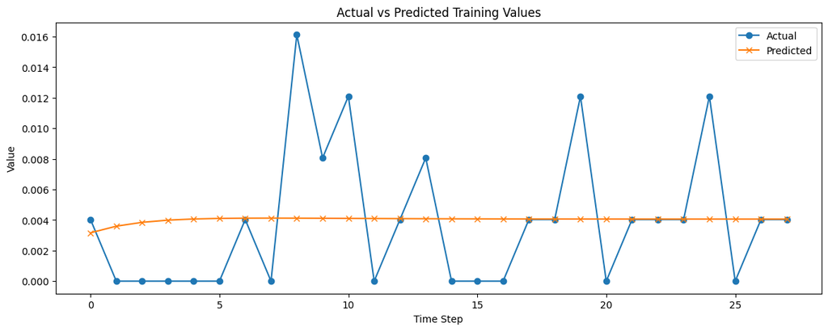

```python
import matplotlib.pyplot as plt
import numpy as np

# Assuming y_train and y_train_predicted are numpy arrays of shape (30490, 28, 1)
# You might need to squeeze them if you want to remove the singleton dimension
y_train = y_train.squeeze()  # Reduces to shape (30490, 28)
y_train_predicted = y_train_predicted.squeeze()  # Reduces to shape (30490, 28)

# Plotting the first sequence as an example
plt.figure(figsize=(14, 5))
plt.plot(y_train[0], label='Actual', marker='o')  # Plot the actual values
plt.plot(y_train_predicted[0], label='Predicted', marker='x')  # Plot the predicted values
plt.title('Actual vs Predicted Training Values')
plt.xlabel('Time Step')
plt.ylabel('Value')
plt.legend()
plt.show()
```

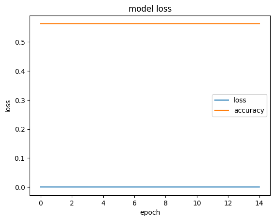

```python
plt.plot(trained_model.history['loss'])
plt.plot(trained_model.history['accuracy'])
plt.title('model loss')
plt.ylabel('loss')
plt.xlabel('epoch')
plt.legend(['loss','accuracy'])
plt.show()
```

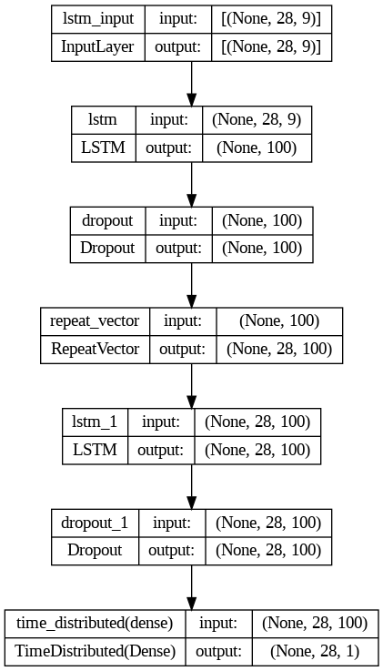

```python
tf.keras.utils.plot_model(lstm_model,show_shapes=True)
```

```python
# Take last 28 days in the past to predict the next 28 days in the future
X_test = np.array(X_train[:, -time_steps:, :]) # Here timesteps=28
X_test = X_test.reshape((X_train.shape[0], time_steps, num_features))
print(X_test.shape)
```

```
(30490, 28, 9)
```

```python
# Predict the next 28 days
y_pred = lstm_model.predict(X_test[:,-time_steps:, :], verbose=2)

# Concatenate prediction with past timesteps
test_forecast = np.concatenate((X_test[:,:,8].reshape(X_test.shape[0],X_test.shape[1]),
                           y_pred.astype(np.float32).reshape(X_test.shape[0],X_test.shape[1])),axis=1).reshape((X_test.shape[0],X_test.shape[1]+28,1))
print(y_pred)
print(test_forecast.shape)
```

```
953/953 - 9s - 9s/epoch - 10ms/step
[[[0.00316262]
  [0.0035971 ]
  [0.00384879]
  ...
  [0.00406064]
  [0.00406039]
  [0.0040602 ]]

 [[0.00243924]
  [0.00241441]
  [0.00237596]
  ...
  [0.00209297]
  [0.0020928 ]
  [0.00209268]]

 [[0.00253628]
  [0.00257887]
  [0.0025873 ]
  ...
  [0.00242474]
  [0.00242459]
  [0.00242449]]

 ...

 [[0.00331728]
  [0.00383869]
  [0.00413906]
  ...
  [0.0044251 ]
  [0.00442485]
  [0.00442466]]

 [[0.00394892]
  [0.00485722]
  [0.00538664]
  ...
  [0.00574687]
  [0.00574639]
  [0.00574605]]

 [[0.00542253]
  [0.00719348]
  [0.00820842]
  ...
  [0.00857816]
  [0.00857738]
  [0.00857683]]]
(30490, 56, 1)
```

```python
print(y_pred.shape)
print(test_forecast.shape)
```

```
(30490, 28, 1)
(30490, 56, 1)
```

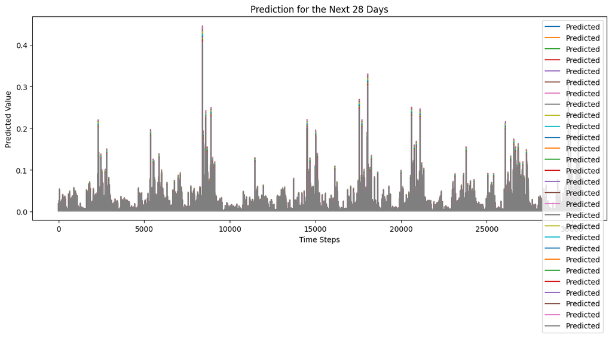

```python
# If you want to plot the first feature for all time steps
y_pred_feature = y_pred[:, :, 0]  # This selects all time steps for the first feature

plt.figure(figsize=(14, 5))
plt.plot(y_pred_feature, label='Predicted')
plt.title('Prediction for the Next 28 Days')
plt.xlabel('Time Steps')
plt.ylabel('Predicted Value')
plt.legend()
plt.show()
```

```python
# Reverse normalize to obtain human interpratable values
test_forecast = FNoramlize(test_forecast,train_low,train_high)

# Round values
test_forecast = np.rint(test_forecast)
```

```python
# Transform into DataFrame and keep only the predictions
predicted_forecast = pd.DataFrame(test_forecast.reshape(test_forecast.shape[0],test_forecast.shape[1])).iloc[:,-28:]
predicted_forecast.columns = [f'F{i}' for i in range(1, predicted_forecast.shape[1] + 1)]
predicted_forecast[predicted_forecast < 0] = 0
predicted_forecast.head()
```

|  | F1 | F2 | F3 | F4 | F5 | F6 | F7 | F8 | F9 | F10 | F11 | F12 | F13 | F14 | F15 | F16 | F17 | F18 | F19 | F20 | F21 | F22 | F23 | F24 | F25 | F26 | F27 | F28 |
| --- | --- | --- | --- | --- | --- | --- | --- | --- | --- | --- | --- | --- | --- | --- | --- | --- | --- | --- | --- | --- | --- | --- | --- | --- | --- | --- | --- | --- |
| 0 | 1.0 | 1.0 | 1.0 | 1.0 | 1.0 | 1.0 | 1.0 | 1.0 | 1.0 | 1.0 | 1.0 | 1.0 | 1.0 | 1.0 | 1.0 | 1.0 | 1.0 | 1.0 | 1.0 | 1.0 | 1.0 | 1.0 | 1.0 | 1.0 | 1.0 | 1.0 | 1.0 | 1.0 |
| 1 | 1.0 | 1.0 | 1.0 | 1.0 | 1.0 | 1.0 | 1.0 | 1.0 | 1.0 | 1.0 | 1.0 | 1.0 | 1.0 | 1.0 | 1.0 | 1.0 | 1.0 | 1.0 | 1.0 | 1.0 | 1.0 | 1.0 | 1.0 | 1.0 | 1.0 | 1.0 | 1.0 | 1.0 |
| 2 | 1.0 | 1.0 | 1.0 | 1.0 | 1.0 | 1.0 | 1.0 | 1.0 | 1.0 | 1.0 | 1.0 | 1.0 | 1.0 | 1.0 | 1.0 | 1.0 | 1.0 | 1.0 | 1.0 | 1.0 | 1.0 | 1.0 | 1.0 | 1.0 | 1.0 | 1.0 | 1.0 | 1.0 |
| 3 | 1.0 | 2.0 | 2.0 | 2.0 | 2.0 | 2.0 | 2.0 | 2.0 | 2.0 | 2.0 | 2.0 | 2.0 | 2.0 | 2.0 | 2.0 | 2.0 | 2.0 | 2.0 | 2.0 | 2.0 | 2.0 | 2.0 | 2.0 | 2.0 | 2.0 | 2.0 | 2.0 | 2.0 |
| 4 | 1.0 | 1.0 | 1.0 | 1.0 | 1.0 | 1.0 | 1.0 | 1.0 | 1.0 | 1.0 | 1.0 | 1.0 | 1.0 | 1.0 | 1.0 | 1.0 | 1.0 | 1.0 | 1.0 | 1.0 | 1.0 | 1.0 | 1.0 | 1.0 | 1.0 | 1.0 | 1.0 | 1.0 |

```python
train_data = pd.read_csv(path+'sales_train_validation.csv')
validation_ids = train_data['id'].values
evaluation_ids = [i.replace('validation', 'evaluation') for i in validation_ids]
```

```python
ids = np.concatenate([validation_ids, evaluation_ids])
```

```python
predictions = pd.DataFrame(ids, columns=['id'])
forecast = pd.concat([predicted_forecast]*2).reset_index(drop=True)
predictions = pd.concat([predictions, forecast], axis=1)
```

```python
predictions.to_csv('MSBA_UMN_2023_submission_WithFeatures.csv', index=False)  #Generate the csv file.
```

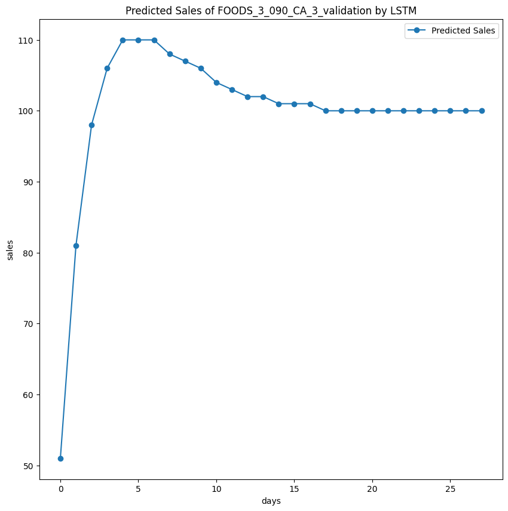

```python
test = pd.read_csv(path + '/test1.csv')
nn=pd.read_csv('MSBA_UMN_2023_submission_WithFeatures.csv')
test.sort_values(['id','date'],inplace=True)
tt=test.pivot_table(index='id',values='sales',columns='d')
tt.reset_index(level=0,inplace=True)
tt['id']=tt['id'].apply(lambda x:x.replace('evaluation','validation'))
pred_sales=nn[nn['id']=='FOODS_3_090_CA_3_validation'].values.flatten()[1:]
plt.figure(figsize=(10,10))
plt.plot(pred_sales,label='Predicted Sales',marker='o')
plt.title("Predicted Sales of FOODS_3_090_CA_3_validation by LSTM")
plt.ylabel('sales')
plt.xlabel('days')
plt.legend()
plt.show()
```

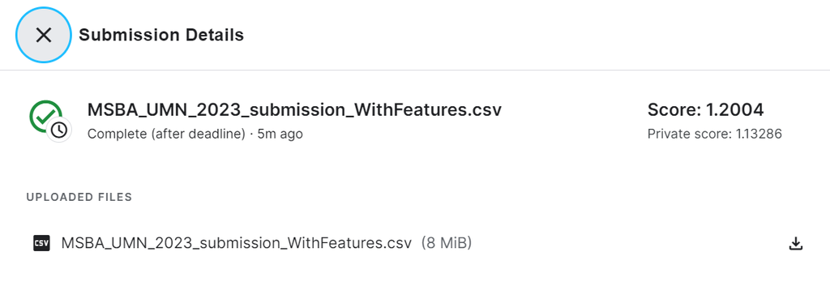